# A36 Speeds

This is a quick look at the BANES/BathHacked data to assess speeds on the Warminster Road section, between the two ANPRs, one at Dry Arch on the entry to Bathampton, and the other on Warminster Rd. This is a distance of 1.53km along the road, according to the site positions published by BANES & BathHacked, and Google Maps. A short distance, about 100m?, is in a 40mph zone, the rest is 30mph.

[figure not shown]

ANPR Distance

First some basic initialisation.

```r
library(dplyr)
library(tidyr)
library(ggplot2)
library(readxl)
library(lubridate)
library(purrr)
library(yarrr)
library(scales)
source("BHTransits_f.R")
a_sep_km <- 1.53
a_sep_M <- a_sep_km * 0.621371192
```

We need to load the data and look for sequences which are westbound (ids 10 then 30), or eastbound (ids 29 then 9). A large number of data points here can end up with still less than 100k average speeds.

```r
#get some observations
obs <- readANPRObs(numobs = -1, beforeDate = "2017-12-01") %>%
  #only identified vehicles
  filter(vehicle_id != "") %>%
  #sequences
  group_by(vehicle_id) %>%
  arrange(time) %>%
  #pick out pairs
  mutate(warm = case_when(
    (site_id == 30) & (lag(site_id) == 10) ~ "W",
    (site_id == 10) & (lead(site_id) == 30) ~ "W",
    (site_id == 9) & (lag(site_id) == 29) ~ "E",
    (site_id == 29) & (lead(site_id) == 9) ~ "E",
    TRUE ~ "U") ) %>%
  #calculate speeds
  filter(warm != "U") %>%
  #get times, only for valid starts of pairs
  mutate(ttime_hrs = if_else(site_id %in% c(10,29), (lead(time) - time)/3600, NA_real_)) %>%
  #filter
  filter(site_id %in% c(10,29)) %>%
  mutate(
    mph = a_sep_M/as.numeric(ttime_hrs),
    #create a time bin
    tbin = lubridate::floor_date(time, "3 hours"),
    dbin = lubridate::floor_date(time, "1 day"))
```

Now we can try some visualisations of the data. Boxplots are easier for statisticians than others, maybe, to read. In a small sample, the median speed was 29.5mph and 25% were faster than 31mph.

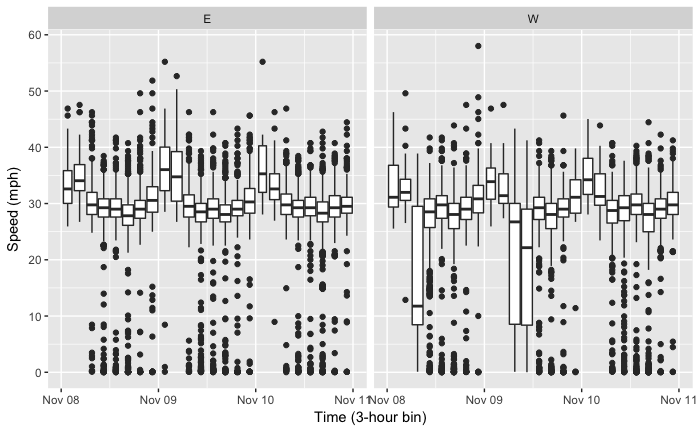

There does seem to be a dip on November 1st for 29-30 sites (Warminster Rd). There are no readings from mid afternoon on the 1st to early morning on the 2nd. This might explain in the Sankey charts in the previous study why there were some vehicles that managed to get from London Road to Dry Arch without being recorded at Warminster Road. It only seems to be that location that is affected, out of the key locations for us: Swainswick, London Rd, Warminster Rd and Bathampton.

Perhaps a bigger surprise is that there is only 2 weeks of data, where I was convinced that there were 4!

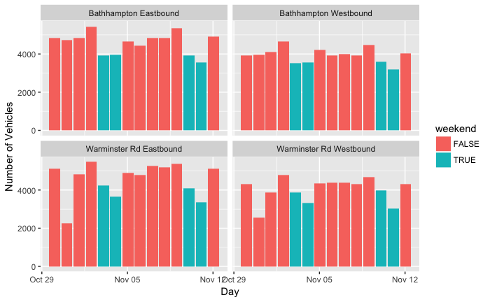

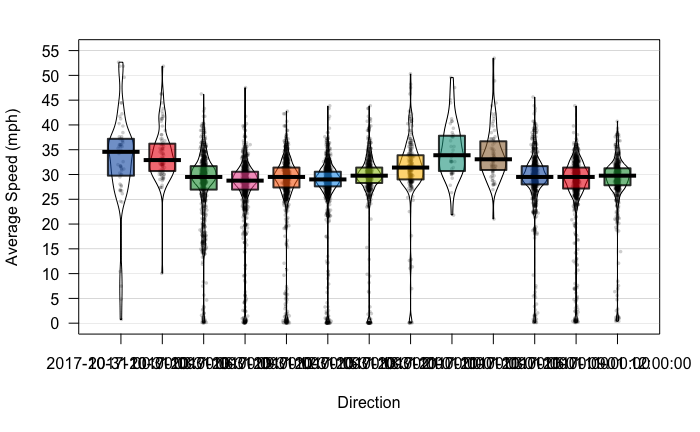

```r
library(yarrr) #for pirate plot
#plot of speed
pp <- pirateplot(formula = mph ~ tbin,
    data = obs,
    avg.line.fun = median,
    ylab = 'Average Speed (mph)',
    xlab = "Direction",
    inf.method = 'iqr',
    theme = 2,
    point.o = 0.2, point.cex = 0.5
    )
```

CUrious to see if there are differences by vehicle type.

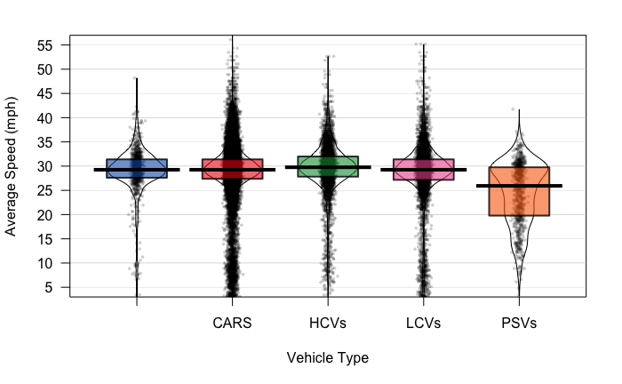

```r
veh <- read.csv("Data/banes_anpr_data/vehicles.csv", stringsAsFactors = F)  %>%
  select(id, type) %>%
  distinct()

obs_v <- obs %>%
  left_join(veh, by= c("vehicle_id" = "id")) %>%
  # almost no SPVs (1 per 2-3 days), so remove them. similarly 2/3 wheelers (2/day)
  filter(!(type %in% c("SPVs", "2/3 Wheelers")))
pp <- pirateplot(formula = mph ~ type,
    data = obs_v,
    avg.line.fun = median,
    ylab = 'Average Speed (mph)',
    xlab = "Vehicle Type",
    inf.method = 'iqr',
    theme = 2,
    point.o = 0.2, point.cex = 0.5,
    ylim = c(5,55)
    )
```

Flip the question around. At a given time of day, what proportion are doing more than 30?

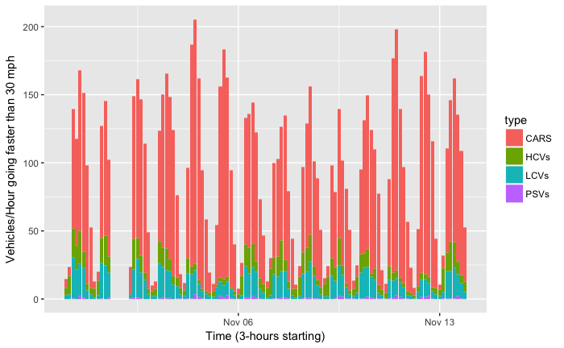

Are the fastest vehicles the emergency vehicles?